# RMarkdown HTML

Brittany MacIntyre

2024-11-15

## Introduction

#### Part 1: Background

R Markdown is a great way to organize code, code comments, and notes and helps generate HTML, PDF or Word reports. We begin with an .Rmd file that contains a combination of:

1. markdown (simple/plain text formatting content)
2. R code (organized in chunks)

In markdown content (non-coding sections), you may write without commenting out lines. Markdown takes plain text with simple formatting cues which can be exported into various formats.

#### Part 2: Knitr

Before we get into some examples, let’s learn how to “knit” our R Markdown file so we can see the output. For this .Rmd file, I selected the output as ‘html_document’ in the YAML header. This is so we can see the output readily in the Viewer pane. I’ll show an example of a PDF output later on.

If we want to render our .Rmd file into its final output format we can either select the ‘Knit’ button next to the settings button or use the shortcut: Shift+Cmd+K (Mac) or Ctrl+Shift+K (Windows/Linux). This is done through the package [knitr](https://yihui.org/knitr/). We will also use the R package [formatR](https://yihui.org/formatr/) to help us tidy and format our code + code comments and Markdown sections.

```r
#install.packages("rmarkdown") # use if you are not prompted to install this package upon opening the .Rmd file
#install.packages("knitr") # may need to install if this is your first time using R Markdown
#install.packages("formatR") # for formatting output documents
library(formatR)
library(tidyverse)
library(viridis)
```

Notice in the viewer pane the code comments are wrapped in an ugly way–yuck.

Using knitr and formatR, we can wrap long code comment text either chunk by chunk as follows, setting the width cut-off as 80 characters:

```r
# install.packages('rmarkdown') # use if you are not prompted to install this
# package upon opening the .Rmd file install.packages('knitr') # may need to
# install if this is your first time using R Markdown
# install.packages('formatR') # for formatting output documents
```

Or, globally by loading knitr, and setting up the width output for all remaining chunks to 60 characters. To do this we need to call `knitr::opts_chunk$set` in a code chunk.

```r
library(knitr)
opts_chunk$set(tidy.opts=list(width.cutoff=60), tidy=TRUE)
```

Let’s see if the above works on the code below which has a very long code comment.

```r
# this is a very very very very very very very very very
# very very very very very very very very very long long
# long long line of text.
```

#### Part 3: Examples of Plain Text Formatting

Some examples of different formatting cues:

A single asterisk surrounding a word or phrase will create *italics*. Double asterisks produce **bold text**.

Lists are created with dashes:

- Dash item 1
- Dash item 2

Or, numbered lists with numbers:

1. Number 1
2. Number 2

You can include [hyperlinked words](https://rmarkdown.rstudio.com/authoring_quick_tour.html#Overview) or hyperlinks of the URL itself http://rmarkdown.rstudio.com with angle brackets or footnotes with square brackets.[^1]

No matter where your bibliography/reference is placed in the document (as above), it will always output either at the end of your HTML document or PDF page.

Additionally, text size for headers can also be generated with the use of ‘#’ (number sign/hash mark/hashtag)

# Header 1

This is one number sign

## Header 2

This is two number signs

### Header 3

This is three number signs

#### Header 4

This is four number signs

Next, let’s try to centre our text! First, we’ll type inside of a pair of angle brackets <>, similar to including a URL hyperlink surrounded by <>. Then we’ll write the text in the line below and end it off by including /center between <>.

This is my centred title :)

What if we want to print out an image?

[figure not shown]

RMarkdown is Great!

What if we want a double ‘space’ after our image? Create a line break with ‘br’ surrounded by <>.

**CHALLENGE 1:** We want to make a centred title, say for your Assignment #5. Create a title or use “Assignment #5” in Header size 2 that is centred in your output document.  
In Markdown, we can even evaluate r expressions inline by eclosing them with ` using the ‘r’ qualifier.

I counted 14 black cats and 3 non-black cats.

## R Code Chunks

R code chunks are initialized by using the backwards dash ` three times in the line above and below a section of code:

```
Text inputted here will create a block of output looking code.
```

`see the difference with just one back tick? This shows up in the HTML format, but not the PDF version`

Adding ‘r’ after a pair curly brackets {} tells R markdown what programming language the chunk will be in.

```r
# I created this code chunk manually!
```

Keyboard shortcuts to quickly insert a code chunk:

1. Mac: Cmd + Option + i
2. Windows/Linux: Ctrl + Alt + i
3. OR add chunk button in the editor toolbar

#### Part A. Chunk Options

We can customize each code chunk with knitr options, which are arguments set inside a pair of curly brackets {} immediatly after the initializing three back ticks for the code chunk.

Here are some example arguments, note the lack of spaces between the equal signs(!):

- `include=FALSE` prevents code and results (output) from appearing in finished file
- `echo=FALSE` prevents code, but not the results (output) from appearing in the finished file (embedded figures)
- `message=FALSE` prevents messages that are generated by code from appearing in the finished file
- `warning=FALSE` prevents warnings that are generated by code from appearing in the finished file
- `fig.cap="..."` adds a caption to a graphical result
- `eval=FALSE` prevents execution/evaluation of code chunk
- `results=hide` prevents text output from appearing in finished file
- `results=asis` text output is written “as is” i.e. you can write out raw markdown text from R code

#### Part C. Figures

Let’s embed a plot into our finalized document, where we only want to see the output and hide the code. We’ll use data from the viridis R package to create a contour map of the Magma palette and give it a figure caption.

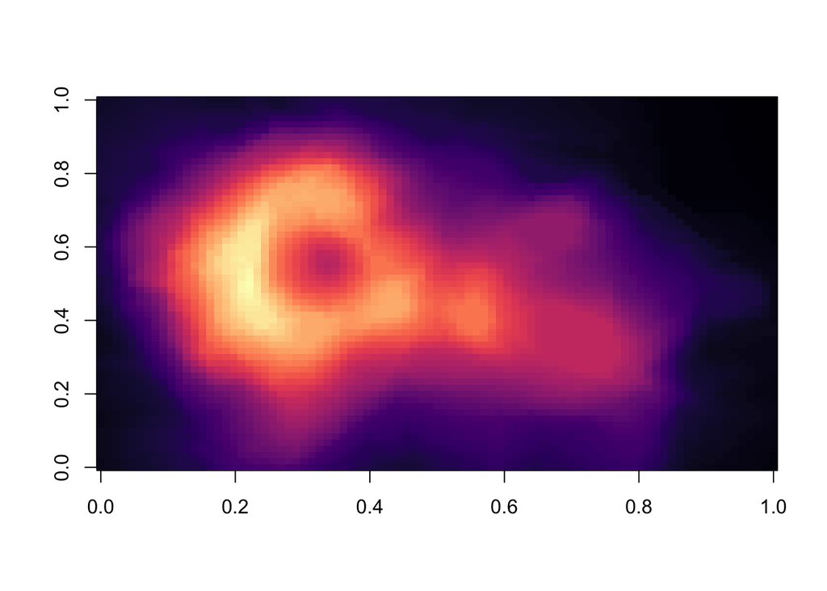

The Maunga Whau Volcano, Auckland

```r
image(volcano, col = viridis(200, option = "A"))
```

Or using the tidyverse dataset ‘starwars’ by centring the figure

```r
data("starwars")
head(starwars)
```

```
## # A tibble: 6 × 14
##   name      height  mass hair_color skin_color eye_color birth_year sex   gender
##   <chr>      <int> <dbl> <chr>      <chr>      <chr>          <dbl> <chr> <chr>
## 1 Luke Sky…    172    77 blond      fair       blue            19   male  mascu…
## 2 C-3PO        167    75 <NA>       gold       yellow         112   none  mascu…
## 3 R2-D2         96    32 <NA>       white, bl… red             33   none  mascu…
## 4 Darth Va…    202   136 none       white      yellow          41.9 male  mascu…
## 5 Leia Org…    150    49 brown      light      brown           19   fema… femin…
## 6 Owen Lars    178   120 brown, gr… light      blue            52   male  mascu…
## # ℹ 5 more variables: homeworld <chr>, species <chr>, films <list>,
## #   vehicles <list>, starships <list>
```

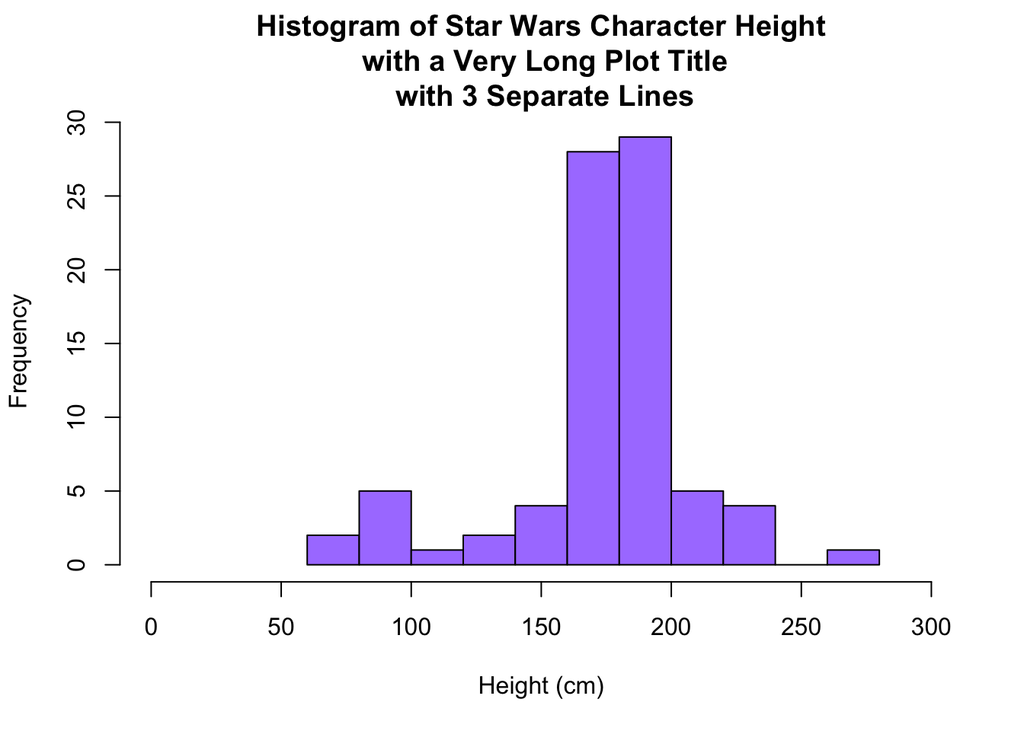

**Figure 1.** Histogram plot of Star Wars Characters

```r
hist(starwars$height, xlab = "Height (cm)", col = "mediumpurple1",
    main = "Histogram of Star Wars Character Height\n with a Very Long Plot Title\n with 3 Separate Lines",
    xlim = c(0, 300))
```

Can we do the same thing, this time with a height histogram plot for gender?

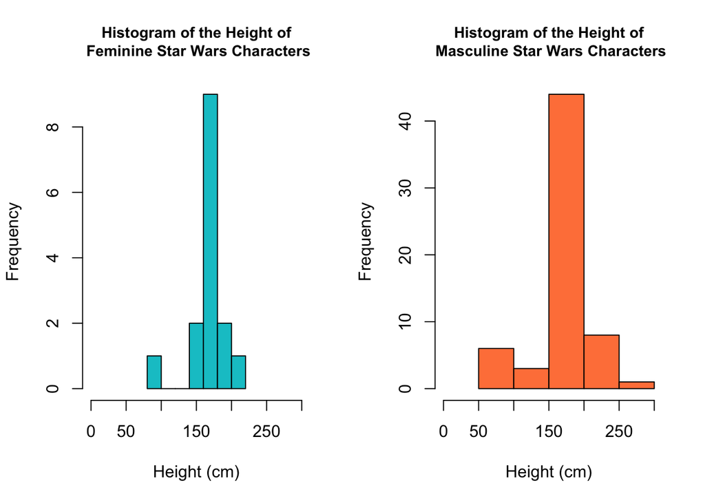

**Figure 2.** Histogram of Star Wars character height for feminine gender (**A**) and masculine gender (**B**)

```r
df_fem <- starwars |>
    filter(gender == "feminine")
df_masc <- starwars |>
    filter(gender == "masculine")

# Create a new plotting window, and set to a 1 'row' x 2
# 'column' array
par(mfrow = c(1, 2))

# Plot feminine character height
hist(df_fem$height, xlab = "Height (cm)", col = "turquoise3",
    main = "Histogram of the Height of\n Feminine Star Wars Characters",
    cex.main = 0.9, xlim = c(0, 300))

# Plot masculine character height
hist(df_masc$height, xlab = "Height (cm)", col = "sienna1", main = "Histogram of the Height of\n Masculine Star Wars Characters",
    cex.main = 0.9, xlim = c(0, 300))
```

#### Part D. Programming Languages

Let’s create a code chunk that uses a different programming language. knitr can execute the following language engines:

- bash
- Python
- SQL
- Rcpp
- Stan
- JavaScript
- CSS

Chunk options work with these languages as well!

##### Bash

```bash
ls *.Rmd
```

```
## RMarkdown.Rmd
```

##### Python

```python
x = 'hello, python world!'
print(x.split(' '))
```

```
## ['hello,', 'python', 'world!']
```

#### Part E. Tables

Easiest way to make beautiful tables in R is with knitr’s `kable` function. Other table generating packages to explore include: xtable, stargazer, pander, tables, and ascii.

A knitr table with Star Wars Characters

| name | height | mass | hair_color | skin_color | eye_color | birth_year | sex | gender | homeworld | species |
| --- | --- | --- | --- | --- | --- | --- | --- | --- | --- | --- |
| Luke Skywalker | 172 | 77 | blond | fair | blue | 19.0 | male | masculine | Tatooine | Human |
| C-3PO | 167 | 75 | NA | gold | yellow | 112.0 | none | masculine | Tatooine | Droid |
| R2-D2 | 96 | 32 | NA | white, blue | red | 33.0 | none | masculine | Naboo | Droid |
| Darth Vader | 202 | 136 | none | white | yellow | 41.9 | male | masculine | Tatooine | Human |
| Leia Organa | 150 | 49 | brown | light | brown | 19.0 | female | feminine | Alderaan | Human |
| Owen Lars | 178 | 120 | brown, grey | light | blue | 52.0 | male | masculine | Tatooine | Human |
| Beru Whitesun Lars | 165 | 75 | brown | light | blue | 47.0 | female | feminine | Tatooine | Human |
| R5-D4 | 97 | 32 | NA | white, red | red | NA | none | masculine | Tatooine | Droid |

[output not shown]

[^1]: R Markdown for RStudio. https://rmarkdown.rstudio.com/authoring_quick_tour.html#Overview